# Simulasi Proses MA(2), AR(2), dan ARMA(2,2)

# Libraries

```r
library(ggplot2)
library(tseries)
```

## Fungsi Bantuan: EACF

Paket `TSA` yang biasa dipakai untuk menghitung *Extended ACF* (EACF) kadang tidak tersedia di semua komputer. Karena itu, fungsi `eacf()` dituliskan ulang di bawah ini (algoritma Chan, 2001) supaya kode tetap bisa dijalankan tanpa instalasi paket tambahan. Cara pakainya sama persis dengan `TSA::eacf()`.

```r
eacf_custom <- function(z, ar.max = 7, ma.max = 13) {
  lag1 <- function(z, lag = 1) c(rep(NA, lag), z[1:(length(z) - lag)])
  reupm <- function(m1, nrow, ncol) {
    k <- ncol - 1
    m2 <- NULL
    for (i in 1:k) {
      i1 <- i + 1
      work <- lag1(m1[, i])
      work[1] <- -1
      temp <- m1[, i1] - work * m1[i1, i1] / m1[i, i]
      temp[i1] <- 0
      m2 <- cbind(m2, temp)
    }
    m2
  }
  ceascf <- function(m, cov1, nar, ncol, count, ncov, z, zm) {
    result <- 0 * seq(1, nar + 1)
    result[1] <- cov1[ncov + count]
    for (i in 1:nar) {
      temp <- cbind(z[-(1:i)], zm[-(1:i), 1:i]) %*% c(1, -m[1:i, i])
      result[i + 1] <- acf(temp, plot = FALSE, lag.max = count, drop.lag.0 = FALSE)$acf[count + 1]
    }
    result
  }
  ar.max <- ar.max + 1
  ma.max <- ma.max + 1
  nar <- ar.max - 1
  nma <- ma.max
  ncov <- nar + nma + 2
  nrow <- nar + nma + 1
  ncol <- nrow - 1
  z <- z - mean(z)
  zm <- NULL
  for (i in 1:nar) zm <- cbind(zm, lag1(z, lag = i))
  cov1 <- acf(z, lag.max = ncov, plot = FALSE, drop.lag.0 = FALSE)$acf
  cov1 <- c(rev(cov1[-1]), cov1)
  ncov <- ncov + 1
  m1 <- matrix(0, ncol = ncol, nrow = nrow)
  for (i in 1:ncol) m1[1:i, i] <- ar.ols(z, order.max = i, aic = FALSE, demean = FALSE, intercept = FALSE)$ar
  eacfm <- NULL
  for (i in 1:nma) {
    m2 <- reupm(m1 = m1, nrow = nrow, ncol = ncol)
    ncol <- ncol - 1
    eacfm <- cbind(eacfm, ceascf(m2, cov1, nar, ncol, i, ncov, z, zm))
    m1 <- m2
  }
  work <- 1:(nar + 1)
  work <- length(z) - work + 1
  symbol <- NULL
  for (i in 1:nma) {
    work <- work - 1
    symbol <- cbind(symbol, ifelse(abs(eacfm[, i]) > 2 / work^.5, "x", "o"))
  }
  rownames(symbol) <- 0:(ar.max - 1)
  colnames(symbol) <- 0:(ma.max - 1)
  cat("AR/MA\n")
  print(symbol, quote = FALSE)
  invisible(list(eacf = eacfm, symbol = symbol))
}

# Fungsi bantu untuk membuat data frame plot time series & scatterplot lag
buat_df_ts <- function(y) data.frame(waktu = seq_along(y), nilai = as.numeric(y))

buat_df_lag <- function(y, k) {
  y <- as.numeric(y)
  n <- length(y)
  data.frame(Yt = y[(k + 1):n], Ytk = y[1:(n - k)])
}
```

# Proses MA(2)

Model yang dibangkitkan adalah:

$$Y_t = e_t + \theta_1 e_{t-1} + \theta_2 e_{t-2}, \quad \theta_1 = 0.4,\
\theta_2 = 0.6$$

# Pembangkitan Data

## Cara Manual

Pembangkitan manual dilakukan dengan membuat white noise $e_t \sim N(0,1)$ terlebih dahulu (ditambah 2 nilai awal sebagai “pemanasan” karena MA(2) butuh $e_{t-1}$ dan $e_{t-2}$), lalu menghitung $Y_t$ sesuai rumus di atas.

```r
set.seed(1502)
n <- 300
theta1 <- 0.4
theta2 <- 0.6

e <- rnorm(n + 2)
Y_manual <- numeric(n)
for (t in 1:n) {
  Y_manual[t] <- e[t + 2] + theta1 * e[t + 1] + theta2 * e[t]
}
Y_manual_ma2 <- ts(Y_manual)
head(Y_manual_ma2, 10)
```

```
## Time Series:
## Start = 1
## End = 10
## Frequency = 1
##  [1] -0.9299753  0.2521173  0.3922814  0.4288943  0.3268380 -0.8644833
##  [7] -0.6730051 -3.7535805 -1.9288433 -2.0907296
```

## Menggunakan `arima.sim()`

```r
set.seed(1502)
Y_sim_ma2 <- arima.sim(model = list(ma = c(theta1, theta2)), n = n)
head(Y_sim_ma2, 10)
```

```
## Time Series:
## Start = 1
## End = 10
## Frequency = 1
##  [1] -0.9299753  0.2521173  0.3922814  0.4288943  0.3268380 -0.8644833
##  [7] -0.6730051 -3.7535805 -1.9288433 -2.0907296
```

Selisih absolut maksimum antara data manual dan `arima.sim()` adalah 0, artinya kedua cara pembangkitan tersebut menghasilkan **deret yang identik**. Hal ini terjadi karena pada pembangkitan MA(2), nilai $Y_t$ merupakan kombinasi linear dari white noise dan nilai lag dari white noise yang sama, sehingga hasil pembangkitan manual dan `arima.sim()` pada pengaturan ini identik. Seluruh eksplorasi (plot, ACF/PACF/EACF, scatterplot, dan autokorelasi) menggunakan `Y_sim_ma2`, mengingat data tersebut identik dengan hasil pembangkitan secara manual.

# Sebaran

## Plot Time Series

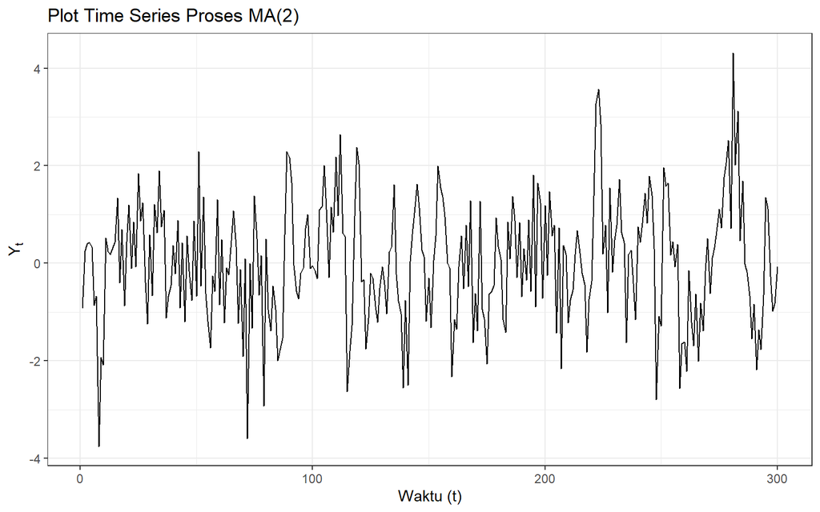

```r
buat_df_ts(Y_sim_ma2) |>
  ggplot(aes(x = waktu, y = nilai)) +
  geom_line() +
  theme_bw() +
  labs(title = "Plot Time Series Proses MA(2)", x = "Waktu (t)", y = expression(Y[t]))
```

## Plot ACF

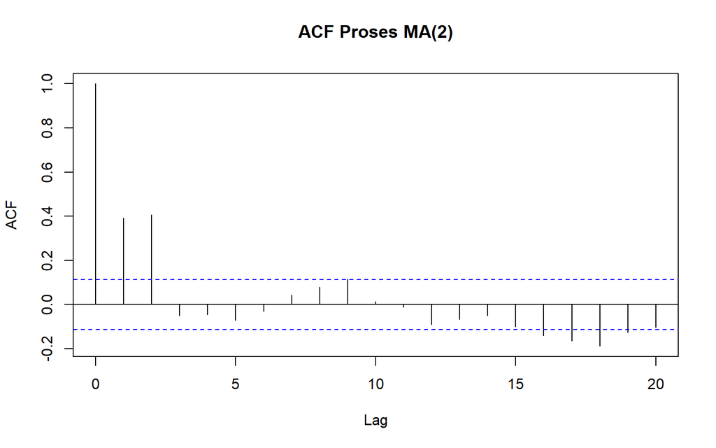

```r
acf(Y_sim_ma2, lag.max = 20, main = "ACF Proses MA(2)")
```

## Plot PACF

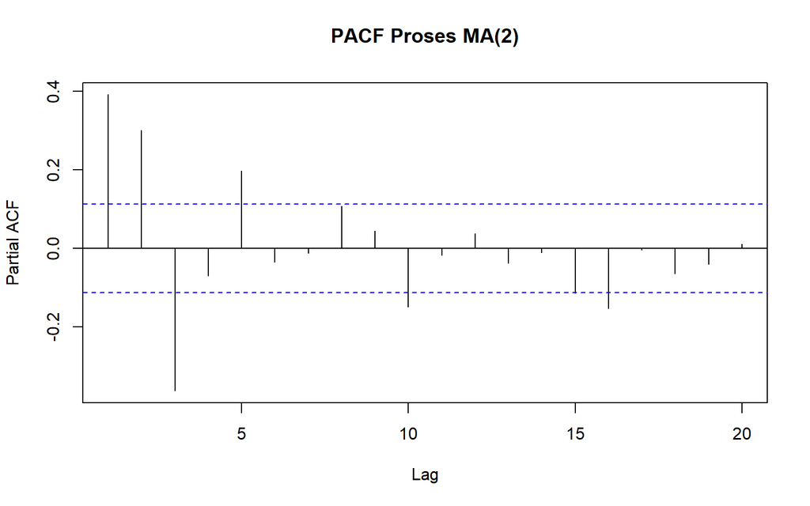

```r
pacf(Y_sim_ma2, lag.max = 20, main = "PACF Proses MA(2)")
```

## Plot EACF

```r
eacf_custom(Y_sim_ma2, ar.max = 5, ma.max = 5)
```

```
## AR/MA
##   0 1 2 3 4 5
## 0 x x o o o o
## 1 x x x o o o
## 2 x x x x o o
## 3 x x x x o o
## 4 x x x x o o
## 5 x o x o x o
```

# Identifikasi Kestasioneran

Model MA murni bersifat stasioner untuk sembarang nilai koefisien MA $θ$, selama error/inovasi merupakan white noise dengan varians hingga. Hal ini terlihat pada hasil eksplorasi:

1. Plot time series berfluktuasi stabil di sekitar rataan nol tanpa tren maupun perubahan lebar pita yang berarti.
2. Plot ACF menunjukkan pola cuts off setelah lag ke-2, sesuai dengan teori bahwa ACF teoritis proses MA(2) bernilai nol untuk lag $k\geq 3$.
3. Plot PACF menurun berangsur/bergelombang (tails off), berkebalikan pola dengan ACF — ciri khas proses MA.
4. Plot EACF menunjukkan segitiga nol (simbol “o”) mulai dari baris AR = 0, kolom MA = 2, yang konsisten dengan identifikasi order MA(2).

Uji formal ADF juga dapat digunakan untuk memastikan kestasioneran dalam rataan:

```r
tseries::adf.test(Y_sim_ma2)
```

```
##
##  Augmented Dickey-Fuller Test
##
## data:  Y_sim_ma2
## Dickey-Fuller = -5.8696, Lag order = 6, p-value = 0.01
## alternative hypothesis: stationary
```

$H_0$: data tidak stasioner $H_1$: data stasioner

Nilai p-value $< 0.05$ yang menyebabkan $H_0$ ditolak, sehingga disimpulkan bahwa data **stasioner dalam rataan**, sesuai dengan hasil eksplorasi visual di atas.

## Scatterplot

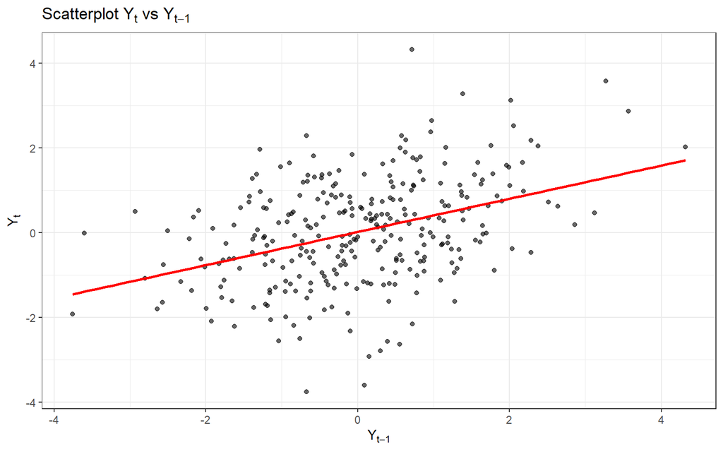

```r
df1 <- buat_df_lag(Y_sim_ma2, 1)
df2 <- buat_df_lag(Y_sim_ma2, 2)
df3 <- buat_df_lag(Y_sim_ma2, 3)

ggplot(df1, aes(x = Ytk, y = Yt)) +
  geom_point(alpha = 0.6) +
  geom_smooth(method = "lm", se = FALSE, color = "red") +
  theme_bw() +
  labs(title = expression(paste("Scatterplot ", Y[t], " vs ", Y[t-1])),
       x = expression(Y[t-1]), y = expression(Y[t]))
```

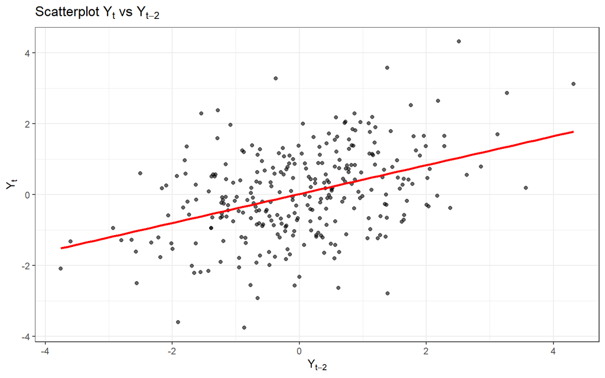

```r
ggplot(df2, aes(x = Ytk, y = Yt)) +
  geom_point(alpha = 0.6) +
  geom_smooth(method = "lm", se = FALSE, color = "red") +
  theme_bw() +
  labs(title = expression(paste("Scatterplot ", Y[t], " vs ", Y[t-2])),
       x = expression(Y[t-2]), y = expression(Y[t]))
```

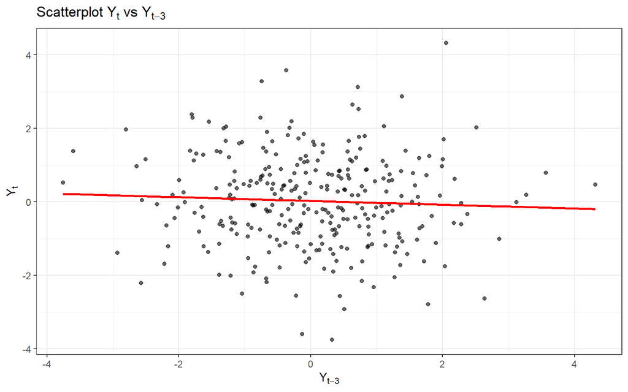

```r
ggplot(df3, aes(x = Ytk, y = Yt)) +
  geom_point(alpha = 0.6) +
  geom_smooth(method = "lm", se = FALSE, color = "red") +
  theme_bw() +
  labs(title = expression(paste("Scatterplot ", Y[t], " vs ", Y[t-3])),
       x = expression(Y[t-3]), y = expression(Y[t]))
```

```r
cat("Korelasi Yt & Yt-1:", round(cor(df1$Yt, df1$Ytk), 4), "\n")
```

```
## Korelasi Yt & Yt-1: 0.3919
```

```r
cat("Korelasi Yt & Yt-2:", round(cor(df2$Yt, df2$Ytk), 4), "\n")
```

```
## Korelasi Yt & Yt-2: 0.4081
```

```r
cat("Korelasi Yt & Yt-3:", round(cor(df3$Yt, df3$Ytk), 4), "\n")
```

```
## Korelasi Yt & Yt-3: -0.0509
```

Scatterplot $Y_t$ vs $Y_{t-1}$ dan $Y_t$ vs $Y_{t-2}$ menunjukkan pola sebaran yang cenderung linear positif, sedangkan scatterplot $Y_t$ vs $Y_{t-3}$ menunjukkan sebaran yang lebih acak tanpa pola linear yang jelas. Hal ini konsisten dengan sifat teoritis proses MA(2), yaitu ACF teoritis bernilai nol untuk lag $k \geq 3$, sehingga hubungan linear antara $Y_t$ dan nilai masa lalu secara teoritis tidak lagi muncul mulai lag ke-3.

# Autokorelasi: Data Bangkitan vs Teoritis

Secara teoritis, untuk proses MA(2):

$$\rho_1 = \frac{\theta_1 + \theta_1\theta_2}{1+\theta_1^2+\theta_2^2},
\qquad
\rho_2 = \frac{\theta_2}{1+\theta_1^2+\theta_2^2}, \qquad
\rho_k = 0 \ \text{untuk } k \geq 3$$

```r
denom <- 1 + theta1^2 + theta2^2
rho1_teori <- (theta1 + theta1 * theta2) / denom
rho2_teori <- theta2 / denom

acf_empiris <- acf(Y_sim_ma2, plot = FALSE, lag.max = 5)$acf[-1]
acf_teoritis <- ARMAacf(ma = c(theta1, theta2), lag.max = 5)[-1]

tabel_banding <- data.frame(
  Lag = 1:5,
  ACF_Data_Bangkitan = round(acf_empiris, 4),
  ACF_Teoritis = round(acf_teoritis, 4)
)
tabel_banding
```

```
##   Lag ACF_Data_Bangkitan ACF_Teoritis
## 1   1             0.3915       0.4211
## 2   2             0.4074       0.3947
## 3   3            -0.0508       0.0000
## 4   4            -0.0456       0.0000
## 5   5            -0.0713       0.0000
```

```r
cat("rho1 (rumus manual):", round(rho1_teori, 4),
    "| rho2 (rumus manual):", round(rho2_teori, 4), "\n")
```

```
## rho1 (rumus manual): 0.4211 | rho2 (rumus manual): 0.3947
```

Nilai $\rho_1$ dan $\rho_2$ hasil perhitungan manual (0.4211dan 0.3947) sama dengan hasil fungsi `ARMAacf()`, dan cukup dekat dengan nilai ACF empiris dari data bangkitan pada lag 1 dan 2, sementara nilai ACF empiris pada lag $\geq 3$ berada di sekitar nol, yang konsisten dengan nilai ACF teoritis proses MA(2) yang bernilai nol pada lag tersebut. Perbedaan kecil antara ACF empiris dan teoritis dapat terjadi akibat variasi atau fluktuasi sampling.

# Proses AR(2)

Model yang dibangkitkan adalah:

$$Y_t = \phi_1 Y_{t-1} + \phi_2 Y_{t-2} + e_t, \quad \phi_1 = 0.5,\ \phi_2
= 0.2$$

# Pembangkitan Data

## Cara Manual

AR(2) bersifat rekursif (nilai sekarang bergantung pada nilai sebelumnya), pembangkitan manual memerlukan periode pemanasan (burn-in) agar efek nilai awal (yang diset nol) hilang sebelum data diambil.

```r
set.seed(2410)
n <- 300
phi1 <- 0.5
phi2 <- 0.2
burn <- 200

e <- rnorm(n + burn)
Y <- numeric(n + burn)
Y[1] <- e[1]
Y[2] <- phi1 * Y[1] + e[2]
for (t in 3:(n + burn)) {
  Y[t] <- phi1 * Y[t - 1] + phi2 * Y[t - 2] + e[t]
}
Y_manual_ar2 <- ts(Y[(burn + 1):(n + burn)])
head(Y_manual_ar2, 10)
```

```
## Time Series:
## Start = 1
## End = 10
## Frequency = 1
##  [1]  1.3694838  0.1765184  0.6385124  0.3883518  0.6238139  1.4614347
##  [7]  1.4775704  1.1486695  0.5871560 -1.0336931
```

## Menggunakan `arima.sim()`

```r
set.seed(2410)
Y_sim_ar2 <- arima.sim(model = list(ar = c(phi1, phi2)), n = n)
head(Y_sim_ar2, 10)
```

```
## Time Series:
## Start = 1
## End = 10
## Frequency = 1
##  [1]  0.08081473  1.16490986  0.86628029 -1.63940171 -0.72799475 -0.48257641
##  [7] -0.05056518  0.70859857  0.23615729  0.90789266
```

Berbeda dengan kasus MA(2), data hasil pembangkitan secara manual dan `arima.sim()` **tidak identik**. Perbedaan tersebut dapat terjadi karena penggunaan periode burn-in dan urutan white noise yang berbeda dalam proses pembangkitan. Meskipun demikian, keduanya menunjukkan karakteristik statistik yang konsisten, seperti rataan yang mendekati 0 dan ragam yang berada pada kisaran yang relatif sama. Oleh karena itu, analisis selanjutnya menggunakan data hasil pembangkitan `Y_sim_ar2`.

# Sebaran

## Plot Time Series

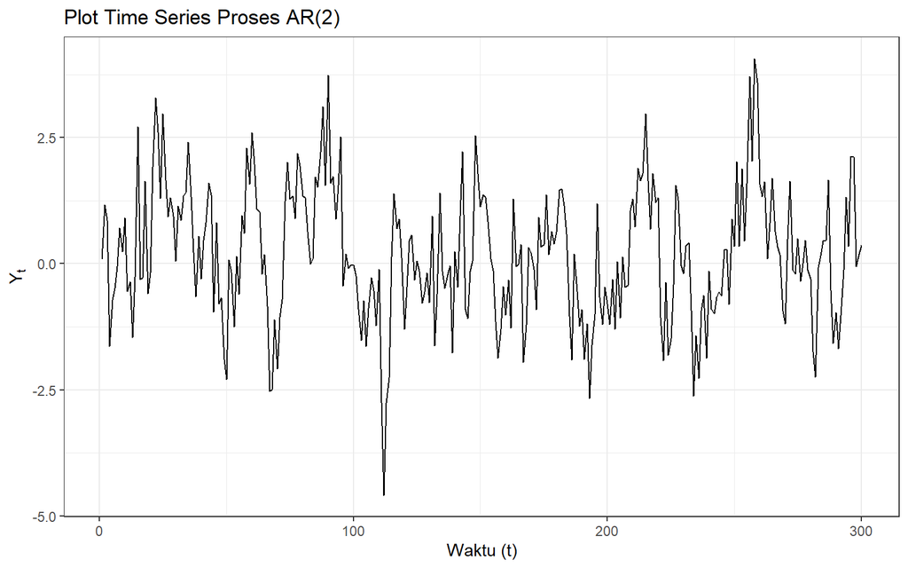

```r
buat_df_ts(Y_sim_ar2) |>
  ggplot(aes(x = waktu, y = nilai)) +
  geom_line() +
  theme_bw() +
  labs(title = "Plot Time Series Proses AR(2)", x = "Waktu (t)", y = expression(Y[t]))
```

## Plot ACF

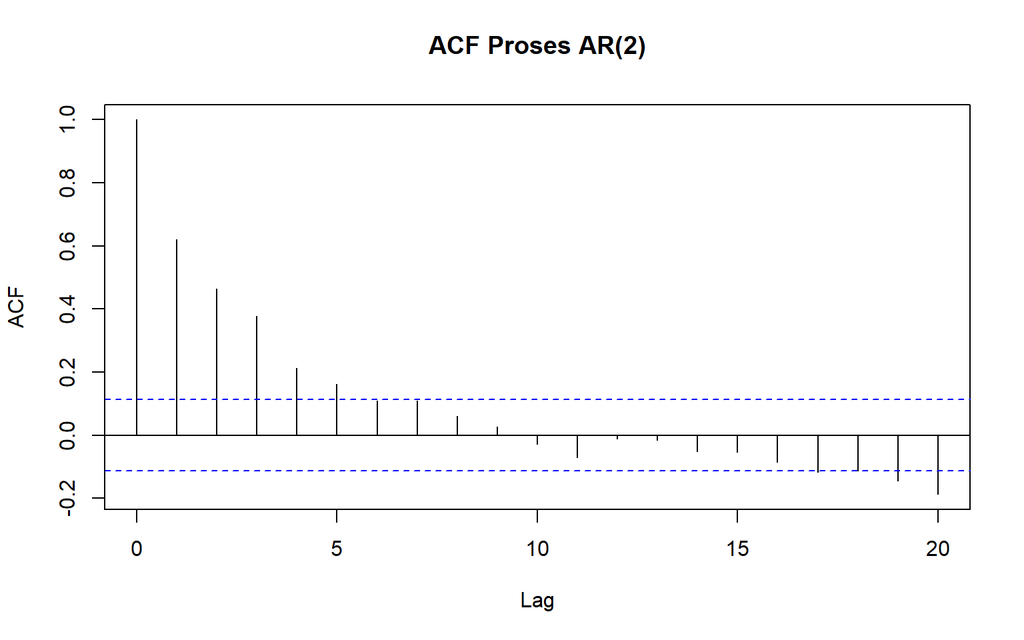

```r
acf(Y_sim_ar2, lag.max = 20, main = "ACF Proses AR(2)")
```

## Plot PACF

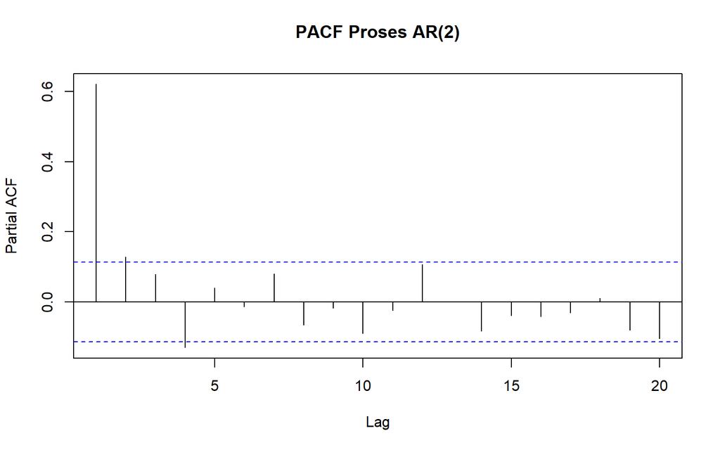

```r
pacf(Y_sim_ar2, lag.max = 20, main = "PACF Proses AR(2)")
```

## Plot EACF

```r
eacf_custom(Y_sim_ar2, ar.max = 5, ma.max = 5)
```

```
## AR/MA
##   0 1 2 3 4 5
## 0 x x x x x o
## 1 x o x x o o
## 2 x o x o o o
## 3 x x o o o o
## 4 x o x o o o
## 5 x o x o o o
```

# Identifikasi Kestasioneran

Syarat kestasioneran AR(2) adalah akar-akar dari persamaan karakteristik:

$1 - \phi_1 z - \phi_2 z^2 = 0$

Berada di luar lingkaran satuan yaitu memiliki modulus (>1). Secara ekuivalen, syarat kestasioneran AR(2) dapat dinyatakan sebagai:

$\phi_1+\phi_2<1$ $\phi_2-\phi_1<1$ $|\phi_2|<1$.

```r
akar <- polyroot(c(1, -phi1, -phi2))
cat("Akar-akar:", akar, "\n")
```

```
## Akar-akar: 1.311738+0i -3.811738+0i
```

```r
cat("Modulus akar:", Mod(akar), "\n")
```

```
## Modulus akar: 1.311738 3.811738
```

```r
cat("Syarat 1 (phi1+phi2 < 1):", phi1 + phi2, "< 1 ->", (phi1 + phi2) < 1, "\n")
```

```
## Syarat 1 (phi1+phi2 < 1): 0.7 < 1 -> TRUE
```

```r
cat("Syarat 2 (phi2-phi1 < 1):", phi2 - phi1, "< 1 ->", (phi2 - phi1) < 1, "\n")
```

```
## Syarat 2 (phi2-phi1 < 1): -0.3 < 1 -> TRUE
```

```r
cat("Syarat 3 (|phi2| < 1)   :", abs(phi2), "< 1 ->", abs(phi2) < 1, "\n")
```

```
## Syarat 3 (|phi2| < 1)   : 0.2 < 1 -> TRUE
```

Ketiga syarat terpenuhi dan modulus kedua akar (1.3117 dan 3.8117) lebih besar dari 1. Dengan demikian, proses AR(2) dengan $\phi_1=0.5$ dan $\phi_2=0.2$ dinyatakan stasioner. Hal ini sejalan dengan hasil eksplorasi:

```r
tseries::adf.test(Y_sim_ar2)
```

```
##
##  Augmented Dickey-Fuller Test
##
## data:  Y_sim_ar2
## Dickey-Fuller = -4.655, Lag order = 6, p-value = 0.01
## alternative hypothesis: stationary
```

Nilai p-value uji ADF $<0.05$ sehingga $H_0$ (terdapat unit root, yaitu data tidak stasioner) ditolak, menguatkan kesimpulan bahwa data **stasioner dalam rataan**.

## Scatterplot

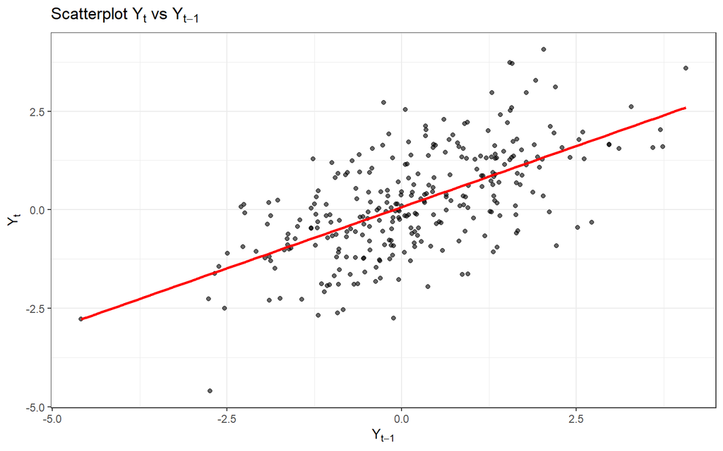

```r
df1 <- buat_df_lag(Y_sim_ar2, 1)
df2 <- buat_df_lag(Y_sim_ar2, 2)
df3 <- buat_df_lag(Y_sim_ar2, 3)

ggplot(df1, aes(x = Ytk, y = Yt)) +
  geom_point(alpha = 0.6) +
  geom_smooth(method = "lm", se = FALSE, color = "red") +
  theme_bw() +
  labs(title = expression(paste("Scatterplot ", Y[t], " vs ", Y[t-1])),
       x = expression(Y[t-1]), y = expression(Y[t]))
```

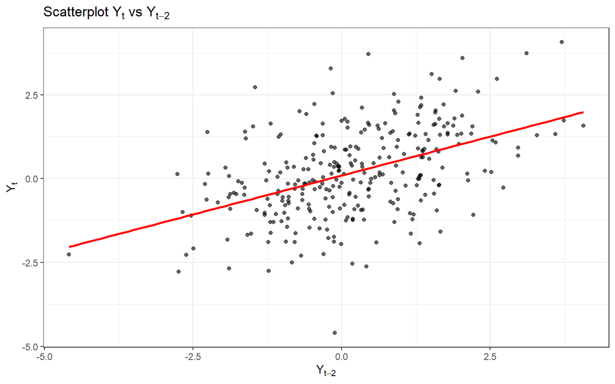

```r
ggplot(df2, aes(x = Ytk, y = Yt)) +
  geom_point(alpha = 0.6) +
  geom_smooth(method = "lm", se = FALSE, color = "red") +
  theme_bw() +
  labs(title = expression(paste("Scatterplot ", Y[t], " vs ", Y[t-2])),
       x = expression(Y[t-2]), y = expression(Y[t]))
```

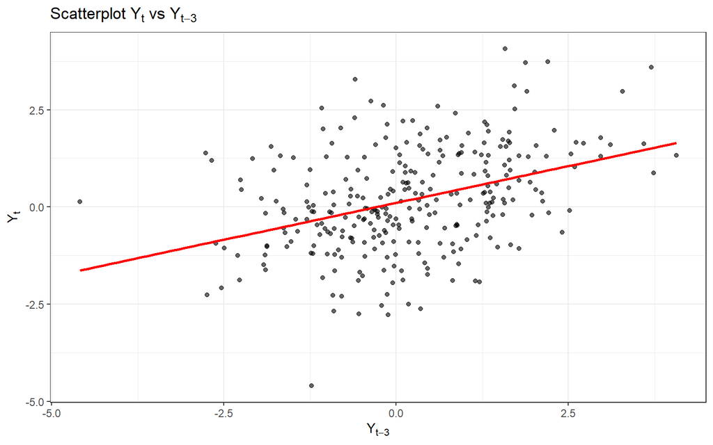

```r
ggplot(df3, aes(x = Ytk, y = Yt)) +
  geom_point(alpha = 0.6) +
  geom_smooth(method = "lm", se = FALSE, color = "red") +
  theme_bw() +
  labs(title = expression(paste("Scatterplot ", Y[t], " vs ", Y[t-3])),
       x = expression(Y[t-3]), y = expression(Y[t]))
```

```r
cat("Korelasi Yt & Yt-1:", round(cor(df1$Yt, df1$Ytk), 4), "\n")
```

```
## Korelasi Yt & Yt-1: 0.6204
```

```r
cat("Korelasi Yt & Yt-2:", round(cor(df2$Yt, df2$Ytk), 4), "\n")
```

```
## Korelasi Yt & Yt-2: 0.464
```

```r
cat("Korelasi Yt & Yt-3:", round(cor(df3$Yt, df3$Ytk), 4), "\n")
```

```
## Korelasi Yt & Yt-3: 0.3786
```

Berbeda dengan MA(2), ketiga scatterplot ($Y_t$ vs $Y_{t-1}$), $Y_{t-2}$, dan $Y_{t-3}$) pada proses AR(2) menunjukkan pola hubungan linear positif, meskipun kekuatan hubungan cenderung melemah seiring bertambahnya lag. Hal ini sesuai dengan karakteristik proses AR, yaitu autokorelasi tidak terputus secara langsung setelah lag tertentu, tetapi cenderung menurun secara bertahap (tails off) seiring bertambahnya lag.

# Autokorelasi: Data Bangkitan vs Teoritis

Secara teoritis, ACF AR(2) diperoleh dari persamaan *Yule-Walker*:

$$\rho_0 = 1, \qquad \rho_1 = \frac{\phi_1}{1-\phi_2}, \qquad \rho_k =
\phi_1 \rho_{k-1} + \phi_2 \rho_{k-2} \ \text{untuk } k \geq 2$$

```r
rho1_teori <- phi1 / (1 - phi2)
rho2_teori <- phi1 * rho1_teori + phi2 * 1
rho3_teori <- phi1 * rho2_teori + phi2 * rho1_teori

acf_empiris <- acf(Y_sim_ar2, plot = FALSE, lag.max = 5)$acf[-1]
acf_teoritis <- ARMAacf(ar = c(phi1, phi2), lag.max = 5)[-1]

tabel_banding <- data.frame(
  Lag = 1:5,
  ACF_Data_Bangkitan = round(acf_empiris, 4),
  ACF_Teoritis = round(acf_teoritis, 4)
)
tabel_banding
```

```
##   Lag ACF_Data_Bangkitan ACF_Teoritis
## 1   1             0.6204       0.6250
## 2   2             0.4635       0.5125
## 3   3             0.3781       0.3812
## 4   4             0.2115       0.2931
## 5   5             0.1626       0.2228
```

```r
cat("rho1 (rumus manual):", round(rho1_teori, 4),
    "| rho2 (rumus manual):", round(rho2_teori, 4),
    "| rho3 (rumus manual):", round(rho3_teori, 4), "\n")
```

```
## rho1 (rumus manual): 0.625 | rho2 (rumus manual): 0.5125 | rho3 (rumus manual): 0.3812
```

Nilai $\rho_1$, $\rho_2$, $\rho_3$ hasil rekursi Yule-Walker manual sama dengan hasil `ARMAacf()`, dan nilainya cukup dekat dengan ACF empiris dari data bangkitan, meskipun tidak identik karena ACF empiris dihitung dari satu realisasi data terbatas (300 observasi) yang secara alami mengandung galat sampling terhadap nilai populasinya.

# Proses ARMA(2,2)

Model yang dibangkitkan adalah gabungan AR(2) dan MA(2):

$$Y_t = \phi_1 Y_{t-1} + \phi_2 Y_{t-2} + e_t + \theta_1 e_{t-1} +
\theta_2 e_{t-2}$$

dengan $\phi_1=0.5,\ \phi_2=0.2,\ \theta_1=0.4,\ \theta_2=0.6$.

# Pembangkitan Data

## Cara Manual

```r
set.seed(3210)
n <- 300
phi1 <- 0.5; phi2 <- 0.2
theta1 <- 0.4; theta2 <- 0.6
burn <- 200

e <- rnorm(n + burn + 2)
Y <- numeric(n + burn)
Y[1] <- e[3]
Y[2] <- phi1 * Y[1] + e[4] + theta1 * e[3]
for (t in 3:(n + burn)) {
  Y[t] <- phi1 * Y[t - 1] + phi2 * Y[t - 2] +
    e[t + 2] + theta1 * e[t + 1] + theta2 * e[t]
}
Y_manual_arma22 <- ts(Y[(burn + 1):(n + burn)])
head(Y_manual_arma22, 10)
```

```
## Time Series:
## Start = 1
## End = 10
## Frequency = 1
##  [1]  0.05092347 -0.40296450 -0.19185272  1.61240080  0.77558411  0.48140270
##  [7] -0.69750123 -0.70769961  0.44556451  1.48016981
```

## Menggunakan `arima.sim()`

```r
set.seed(3210)
Y_sim_arma22 <- arima.sim(model = list(ar = c(phi1, phi2), ma = c(theta1, theta2)), n = n)
head(Y_sim_arma22, 10)
```

```
## Time Series:
## Start = 1
## End = 10
## Frequency = 1
##  [1] 1.5097075 1.3875267 1.4344044 1.5298983 1.8192025 2.7635190 1.9917285
##  [8] 1.4362464 1.4736401 0.7215336
```

Ini sama seperti proses AR(2), karena terdapat komponen AR yang bersifat rekursif, hasil pembangkitan secara manual dan `arima.sim()` tidak identik secara nilai per nilai. Namun, keduanya menunjukkan karakteristik statistik yang konsisten sebagai proses ARMA(2,2). Analisis selanjutnya menggunakan data hasil pembangkitan `Y_sim_arma22`.

# Sebaran

## Plot Time Series

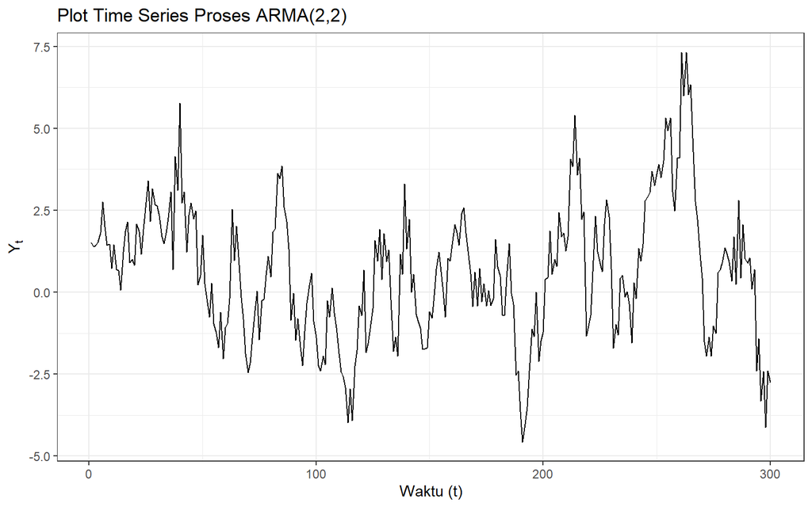

```r
buat_df_ts(Y_sim_arma22) |>
  ggplot(aes(x = waktu, y = nilai)) +
  geom_line() +
  theme_bw() +
  labs(title = "Plot Time Series Proses ARMA(2,2)", x = "Waktu (t)", y = expression(Y[t]))
```

## Plot ACF

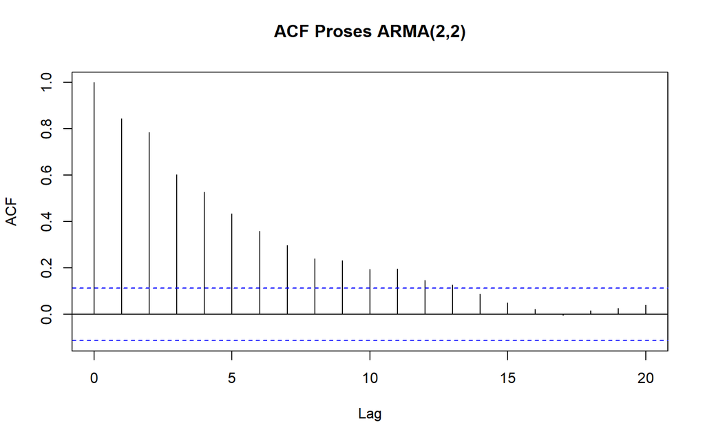

```r
acf(Y_sim_arma22, lag.max = 20, main = "ACF Proses ARMA(2,2)")
```

## Plot PACF

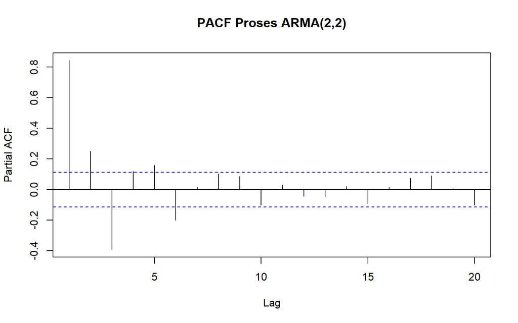

```r
pacf(Y_sim_arma22, lag.max = 20, main = "PACF Proses ARMA(2,2)")
```

## Plot EACF

```r
eacf_custom(Y_sim_arma22, ar.max = 5, ma.max = 5)
```

```
## AR/MA
##   0 1 2 3 4 5
## 0 x x x x x x
## 1 x x x o o o
## 2 x x x o o o
## 3 x x o o o o
## 4 x x x o o o
## 5 x x x o o o
```

# Identifikasi Kestasioneran

Kestasioneran ARMA(2,2) ditentukan oleh komponen AR-nya sedangkan komponen MA tidak memberikan syarat tambahan untuk kestasioneran. Oleh karena itu, syarat kestasioneran ARMA(2,2) sama seperti pada AR(2), yaitu akar-akar persamaan

$1-\phi_1 z-\phi_2 z^2=0$

Berada di luar lingkaran satuan atau memiliki modulus lebih besar dari 1.

```r
akar <- polyroot(c(1, -phi1, -phi2))
cat("Modulus akar AR:", Mod(akar), "\n")
```

```
## Modulus akar AR: 1.311738 3.811738
```

Parameter $\phi_1$ dan $\phi_2$ yang digunakan sama dengan bagian AR(2) sebelumnya, modulus akarnya juga sama (1.3117 dan 3.8117, keduanya $>1$), sehingga proses stasioner. Ini terlihat dari:

```r
tseries::adf.test(Y_sim_arma22)
```

```
##
##  Augmented Dickey-Fuller Test
##
## data:  Y_sim_arma22
## Dickey-Fuller = -4.0483, Lag order = 6, p-value = 0.01
## alternative hypothesis: stationary
```

Nilai p-value uji ADF $< 0.05$ sehingga $H_0$ ditolak dan data dinyatakan **stasioner dalam rataan**, konsisten dengan hasil eksplorasi visual.

## Scatterplot

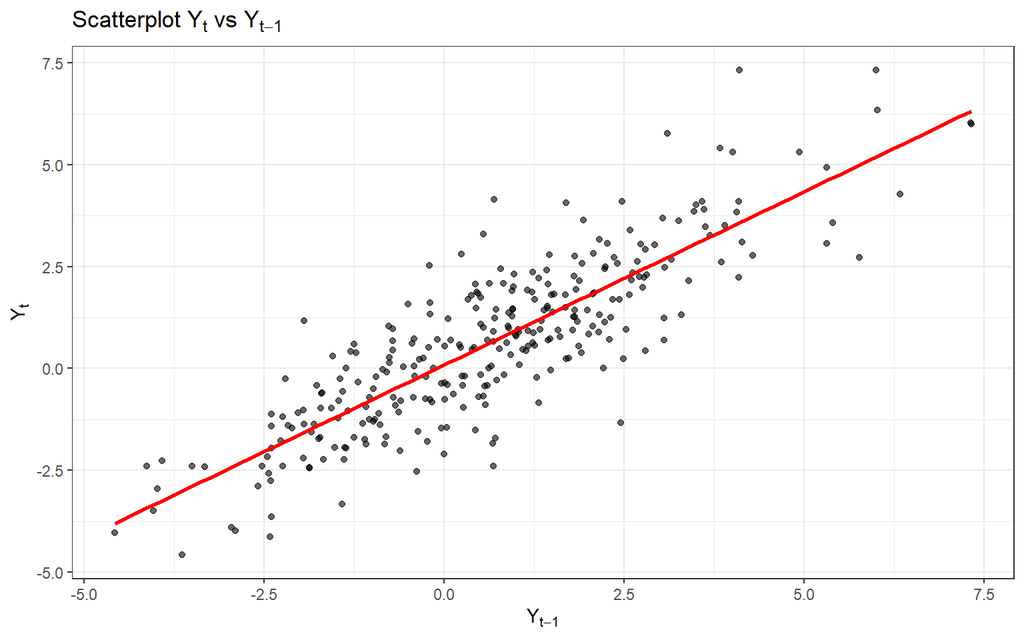

```r
df1 <- buat_df_lag(Y_sim_arma22, 1)
df2 <- buat_df_lag(Y_sim_arma22, 2)
df3 <- buat_df_lag(Y_sim_arma22, 3)

ggplot(df1, aes(x = Ytk, y = Yt)) +
  geom_point(alpha = 0.6) +
  geom_smooth(method = "lm", se = FALSE, color = "red") +
  theme_bw() +
  labs(title = expression(paste("Scatterplot ", Y[t], " vs ", Y[t-1])),
       x = expression(Y[t-1]), y = expression(Y[t]))
```

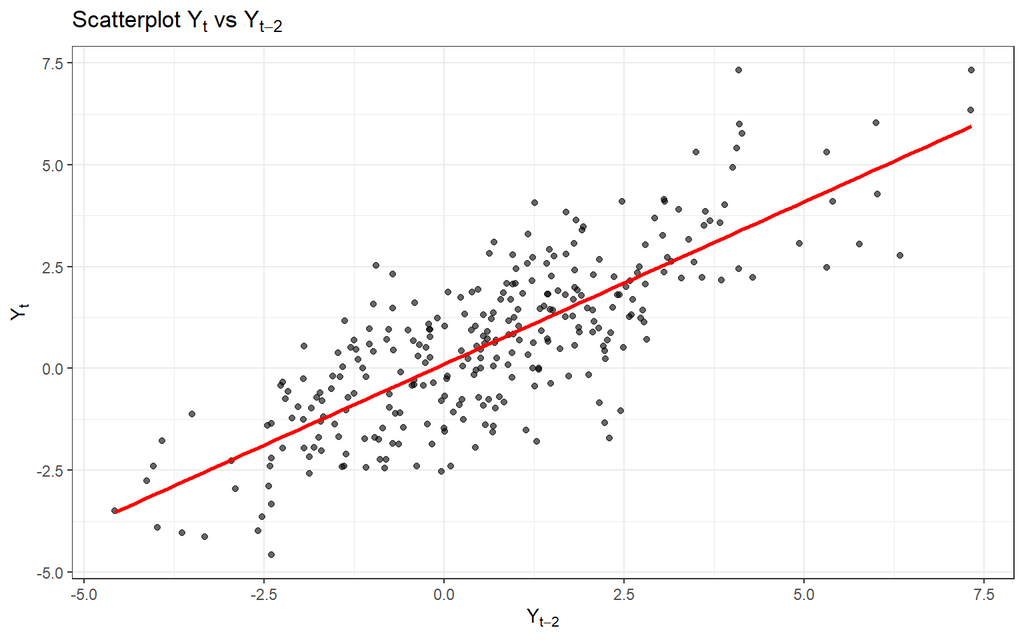

```r
ggplot(df2, aes(x = Ytk, y = Yt)) +
  geom_point(alpha = 0.6) +
  geom_smooth(method = "lm", se = FALSE, color = "red") +
  theme_bw() +
  labs(title = expression(paste("Scatterplot ", Y[t], " vs ", Y[t-2])),
       x = expression(Y[t-2]), y = expression(Y[t]))
```

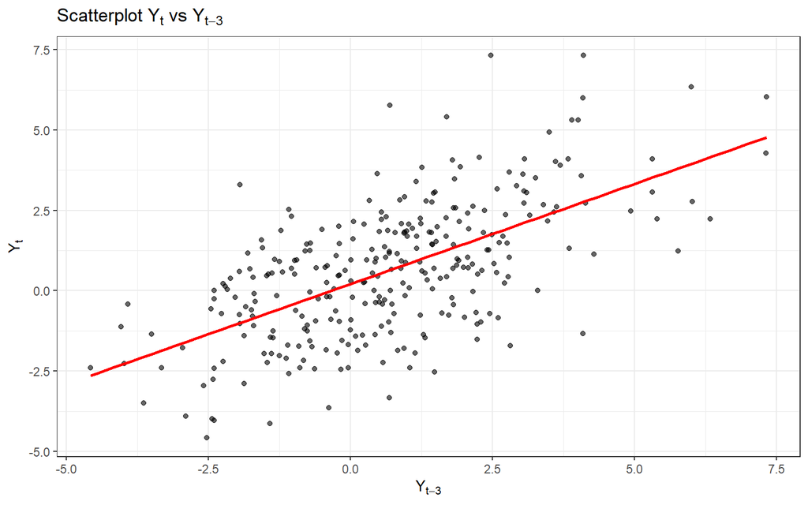

```r
ggplot(df3, aes(x = Ytk, y = Yt)) +
  geom_point(alpha = 0.6) +
  geom_smooth(method = "lm", se = FALSE, color = "red") +
  theme_bw() +
  labs(title = expression(paste("Scatterplot ", Y[t], " vs ", Y[t-3])),
       x = expression(Y[t-3]), y = expression(Y[t]))
```

```r
cat("Korelasi Yt & Yt-1:", round(cor(df1$Yt, df1$Ytk), 4), "\n")
```

```
## Korelasi Yt & Yt-1: 0.8476
```

```r
cat("Korelasi Yt & Yt-2:", round(cor(df2$Yt, df2$Ytk), 4), "\n")
```

```
## Korelasi Yt & Yt-2: 0.7911
```

```r
cat("Korelasi Yt & Yt-3:", round(cor(df3$Yt, df3$Ytk), 4), "\n")
```

```
## Korelasi Yt & Yt-3: 0.6128
```

Ketiga scatterplot menunjukkan pola linear positif, dengan kekuatan hubungan yang berbeda antar-lag. Hubungan tersebut cenderung melemah seiring bertambahnya lag karena dipengaruhi oleh kombinasi komponen AR dan MA dalam proses ARMA(2,2).

# Autokorelasi: Data Bangkitan vs Teoritis

$\rho_k=\phi_1\rho_{k-1}+\phi_2\rho_{k-2}$

```r
acf_empiris <- acf(Y_sim_arma22, plot = FALSE, lag.max = 5)$acf[-1]
acf_teoritis <- ARMAacf(ar = c(phi1, phi2), ma = c(theta1, theta2), lag.max = 5)[-1]

tabel_banding <- data.frame(
  Lag = 1:5,
  ACF_Data_Bangkitan = round(acf_empiris, 4),
  ACF_Teoritis = round(acf_teoritis, 4)
)
tabel_banding
```

```
##   Lag ACF_Data_Bangkitan ACF_Teoritis
## 1   1             0.8435       0.8592
## 2   2             0.7842       0.7492
## 3   3             0.6017       0.5464
## 4   4             0.5273       0.4231
## 5   5             0.4351       0.3208
```

Nilai ACF teoritis pada lag 1 hingga 2 dipengaruhi oleh kombinasi komponen AR dan MA, sehingga polanya tidak harus mengikuti bentuk sederhana seperti pada AR atau MA murni. Untuk lag (k>2), ACF mengikuti rekursi dari komponen AR(2), yaitu

$\rho_k=\phi_1\rho_{k-1}+\phi_2\rho_{k-2}$.

Nilai ACF dari data bangkitan mengikuti pola yang serupa dengan ACF teoritis, meskipun terdapat selisih kecil akibat variasi sampling. Hal ini menunjukkan bahwa karakteristik autokorelasi data bangkitan konsisten dengan model ARMA(2,2) yang ditetapkan.

# Kesimpulan

Berdasarkan hasil analisis, proses MA(2) menunjukkan karakteristik ACF yang cuts off setelah lag ke-2 dan PACF yang tails off, sedangkan proses AR(2) menunjukkan ACF yang tails off dan PACF yang cuts off setelah lag ke-2. Pada proses ARMA(2,2), ACF dan PACF sama-sama menunjukkan pola tails off. Pola tersebut secara umum sesuai dengan teori identifikasi model Box-Jenkins, yaitu MA(q) ditandai oleh ACF yang cuts off pada lag $q$, AR(p) ditandai oleh PACF yang cuts off pada lag $p$, sedangkan ARMA(p,q) umumnya memiliki ACF dan PACF yang sama-sama tails off. Ketiga proses yang dibangkitkan juga memenuhi kondisi kestasioneran masing-masing, yaitu MA(2) stasioner dengan asumsi inovasi memiliki varians hingga, sedangkan AR(2) dan ARMA(2,2) stasioner karena akar polinomial AR berada di luar lingkaran satuan. Hasil uji ADF mendukung kesimpulan bahwa data bangkitan bersifat stasioner dalam rataan. Selain itu, perbandingan antara ACF teoritis dan ACF empiris menunjukkan pola yang serupa, meskipun terdapat perbedaan kecil akibat variasi sampling. Secara keseluruhan, hasil eksplorasi melalui plot time series, ACF, PACF, EACF, uji ADF, dan perbandingan ACF teoritis dengan empiris menunjukkan karakteristik yang konsisten dengan masing-masing model MA(2), AR(2), dan ARMA(2,2).